# Homework 9

2. Johnson & Johnson Earnings: The quarterly earnings per share for 1960-1980 of the U.S. company Johnson & Johnson.
1. Plot the time series and also the logarithm of the series. Argue that we should transform by logs to model this series.

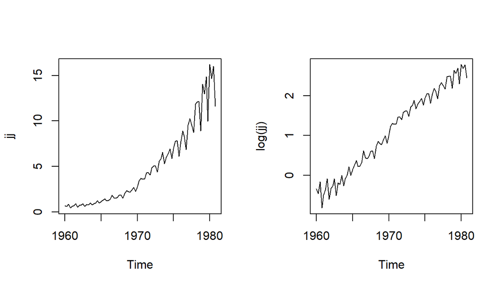

We should transform series `jj` using log-transformation to have smaller changes between times. On the left plot, the changes from a lag to another lag have bigger change. On the plot on the right side, the changes are smaller; and the scale is smaller which is easier to work with.

2. The series is clearly not stationary. Display 3 plots: 1) the first differences, 2) seasonal differences 3) and the seasonal differences with the first differences. Recall that for quarterly data, a season is of length 4. Does the third plot stationarity now seem reasonable?

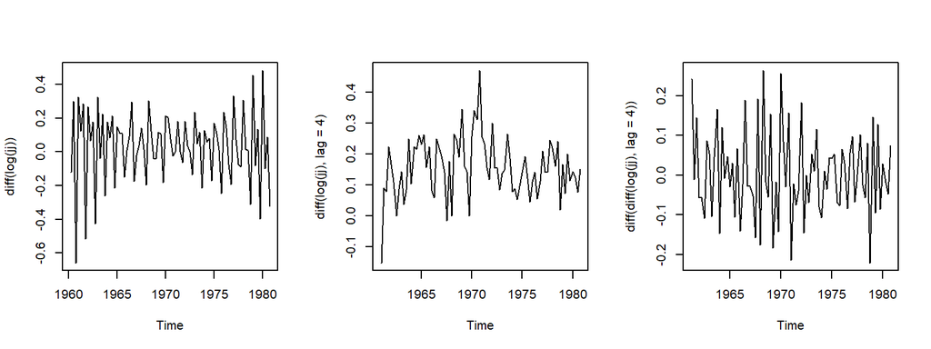

After taking the seasonal differences with the first differences of series `jj`, the process seems more stationary now (see the third plot on the right).

3. Plot and interpret the sample ACF of seasonal differences with the first differences. (Hint: This is part (b) 3))

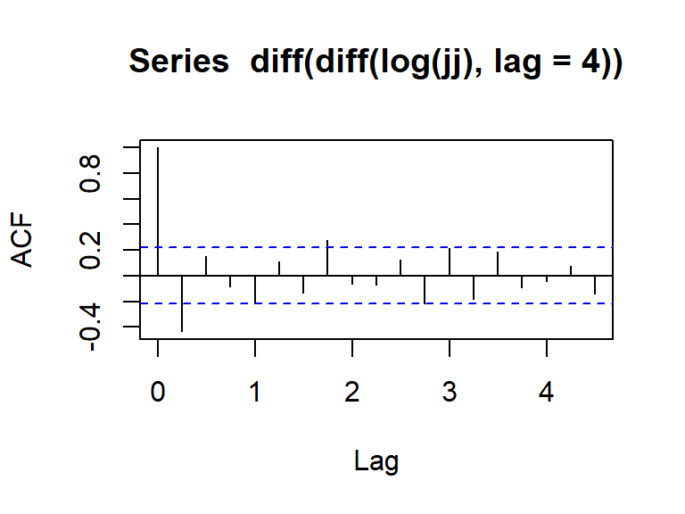

4. Fit the model ARIMA(0,1,1)×(0,1,1)4, and assess the significance of the estimated coefficients.

```
##
## Call:
## arima(x = log(jj), order = c(0, 1, 1), seasonal = list(order = c(0, 1, 1)))
##
## Coefficients:
##           ma1     sma1
##       -0.6809  -0.3146
## s.e.   0.0982   0.1070
##
## sigma^2 estimated as 0.007931:  log likelihood = 78.38,  aic = -150.75
```

```
##           2.5 %     97.5 %
## ma1  -0.8733838 -0.4883582
## sma1 -0.5242504 -0.1048751
```

The confident interval for `fit1` for coefficient `ma1` and `sma1` don’t contain 0 in the intervals. This indicate that the estimated coefficients are signficant.

5. Make diagnostics plots using the R function tsdiag. In addition, include a normal Q-Q plot of the residuals. How well does the model fit the data?

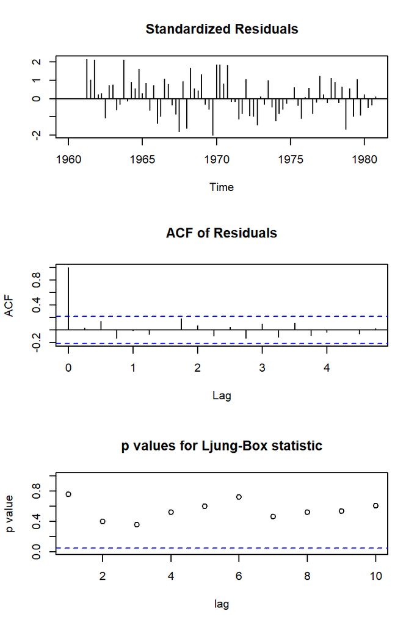

The residuals seem to be random and doesn’t seem to have any pattern. The ACF plot looks like white noise with one one peak at lag 0 and no peaks at other lag which is good. p-value plot seems to be high. There are no low p-values near 0 which is good.

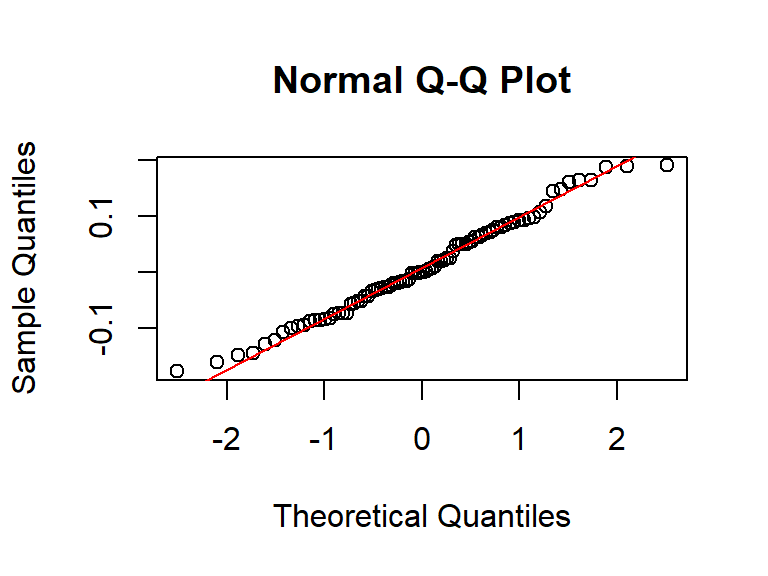

QQ plot of residuals looks normal since it’s on the red line. Therefore, this model is fit the data quite well.

6. Forecasts for the next two years of the series. Be sure to include forecast limits. Include the plot.

Here are the quarterly predictions of the two years ahead:

```
##          Qtr1     Qtr2     Qtr3     Qtr4
## 1981 18.27151 16.84226 18.39626 13.21147
## 1982 20.83116 19.20170 20.97340 15.06227
```

Upper 95% prediction intervals of the quartlerly predictions of the two years ahead:

```
##          Qtr1     Qtr2     Qtr3     Qtr4
## 1981 21.83362 20.30464 22.36629 16.19320
## 1982 27.31471 25.59533 28.39496 20.69589
```

Lower 95% prediction intervals of the quartlerly predictions of the two years ahead:

```
##          Qtr1     Qtr2     Qtr3     Qtr4
## 1981 15.29054 13.97029 15.13092 10.77878
## 1982 15.88658 14.40517 15.49161 10.96217
```

Plot of the forcases and log forecasts:

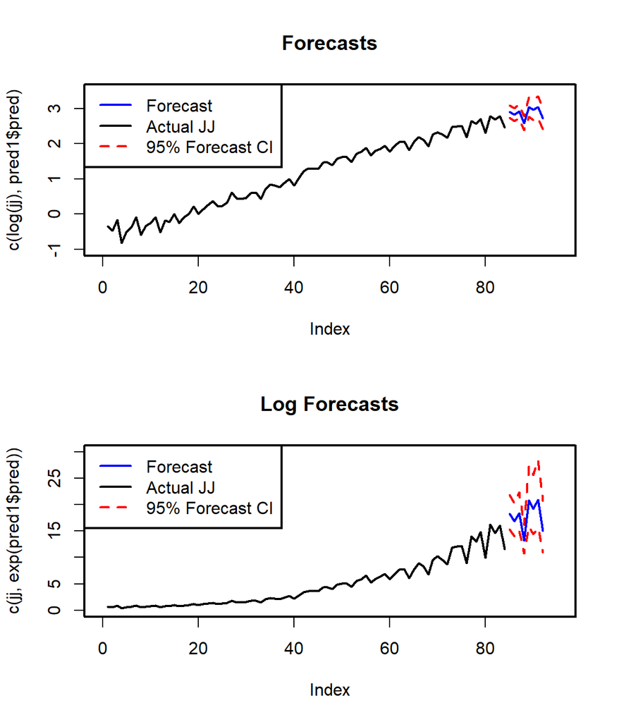